# #ManyDaughters: Preregistered Analyses

Felix Holzmeister

2026-10-22

# Preamble

This `.Rmd` file generates a report of the preregistered analyses. Unless stated otherwise, all analyses strictly follow the pre-analysis plan available at [osf.io/cny7d/](https://osf.io/cny7d/overview). For hypothesis testing, we adopt the thresholds proposed by [Benjamin et al. (2018)](https://doi.org/10.1038/s41562-017-0189-z): results with $p$ < 0.005 are considered “statistically significant,” while results with $p$ < 0.05 are considered providing “suggestive evidence.” All tests rely on two-sided $p$-values. Independent-samples $t$-tests assume equal variances between the groups being compared.

The analyses below are grouped into primary descriptive analyses, primary hypothesis tests, secondary hypothesis tests, robustness tests, and exploratory analyses. The primary descriptive analyses form part of the study’s core results but are not considered hypothesis tests. All analyses and tests are further organized into two thematic areas. The first focuses on the hypotheses examined by the research teams, specifically those concerning the effects of having daughters on various outcomes. The second addresses the effects of accessing data on pre-analysis plans and results.

As specified in our pre-analysis plan, all analyses — unless stated otherwise — include all research teams that completed the entire project, defined as completing all stages of the project and answering all surveys. Seven teams produced analyses that yielded improper statistical estimates (e.g., standard errors equal to zero) for at least one of the four tested hypotheses. These teams are excluded (**not preregistered**) from all analyses that involve research teams’ results. However, they are retained in all analyses in which the hypothesis-related estimates do not enter.

In our preregistered robustness tests, we exclude teams based on two indicators. **(i)** We exclude research teams whose average demeaned analysis reasonableness rating falls below $-2 \times SD$ for a given hypothesis. These exclusions ensure that the analysis focuses on variation in results among teams whose analyses are perceived as reasonable. **(ii)** We also exclude outliers in the $z$-values obtained by implementing the research teams’ analyses for each hypothesis. Outliers are identified using Tukey’s fences (Tukey, 1977) and are defined as observations below $Q1 - 3 \times (Q3-Q1)$ or above $Q3 + 3 \times (Q3-Q1)$, where $Q1$ and $Q3$ are the first and third quartile, respectively. Outliers are identified separately for the data and control groups, as well as for each of the four hypotheses.

The two criteria are applied jointly, in a single “excl. outliers” sample, rather than one at a time. This follows §3.1.1, which states that the outlier exclusion is “in addition to the previous exclusion criterion” and reports “an additional set of descriptive results after applying the above exclusions.” Outlier status is determined on the full sample, before the reasonableness exclusion is applied, as the pre-analysis plan prescribes.

**Non-preregistered deviation — a corrected version of the low-reasonableness exclusion.** Feedback from the participating research teams uncovered an inconsistency in criterion **(i)** as registered: an RT-level *average* of (approximately ten) demeaned ratings is compared against a threshold scaled by the standard deviation of the *individual* demeaned ratings. Averages are far less dispersed than individual ratings (by roughly $\sqrt{10}$), so the registered $-2 \times SD$ threshold is effectively out of reach; it excludes no research team for any hypothesis, and the registered “excl. outliers” sample is determined by the Tukey’s-fences criterion alone. The registered rule remains the rule of record and underlies all preregistered analyses below. In addition, we report a corrected version as a labeled deviation: the same rule, with the standard deviation taken over the distribution of the RT-level average demeaned ratings per hypothesis. The outlier-excluded descriptive statistics and the robustness versions of Primary hypothesis 1a-d and Primary hypothesis 2 are re-estimated under the corrected rule where they occur below; these re-estimations are **not preregistered**. Exclusion counts under both rules are reported in `02_summary_stats.Rmd`.

# Theme 1: RT hypotheses

## Primary descriptive analyses

We will present these results for all RTs. To test robustness and assess the impact of removing low-quality and extreme cases, we will also report an additional set of descriptive results after excluding *(i)* research teams with low peer-rated analysis quality and *(ii)* statistical outliers.

**Results:** The left-hand subpanels in the figure below display the $z$-values obtained by each research team for each of the four hypotheses, sorted from lowest to highest (per hypothesis). The sample comprises all estimates by research teams who delivered proper results for all four hypotheses ($n$ = 120). Error bars indicate 95% CIs, determined as $z \pm \Phi^{-1}(\frac{\alpha}{2})$. Hollow markers indicate estimates flagged as outliers (i.e., observations excluded in preregistered robustness analyses) as per the exclusion criteria detailed in the pre-analysis plan. The gray shaded regions indicate estimates that are statistically significant at the $\alpha$ = 5% level in either direction. The right-hand subpanels show the mean $z$-values by treatment condition; hollow markers carrying a cross depict means for the sample excluding outlying observations. Error bars around the means indicate approximate 95% CIs ($m \pm 1.96$): because the research teams’ $z$-values are not independent, each group’s mean $z$ is treated as a single standard-normal statistic ($se$ = 1) — the same convention as for the individual estimates in the left-hand subpanels. As these intervals replace the registered bootstrapped standard errors, they are **not preregistered** (see the deviation note in the Primary hypothesis 1a-d section). Because the data exhibit substantial variation, the $y$-axes use a signed log scale.

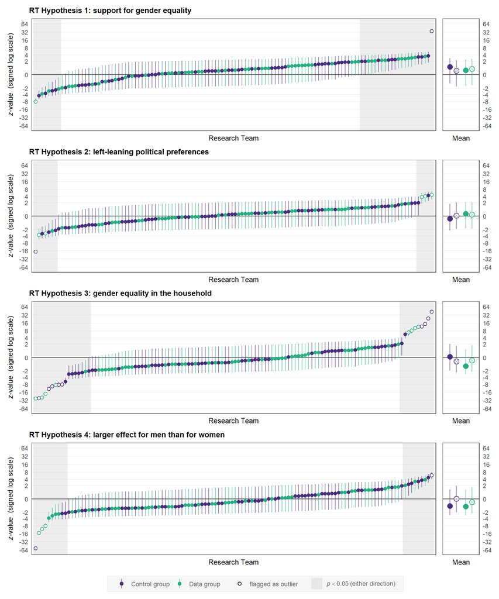

The table below reports, for each of the four hypotheses, the mean $z$-value ($m$), the $p$-value implied by treating the mean $z$ as a standard-normal test statistic, the standard deviation of $z$-values ($sd$), and the 95% CI for the standard deviation. These quantities are tabulated **(i)** for the pooled sample and **(ii)** separately for the two treatment conditions (*data*, *control*). Results are presented for **(a)** the full sample (preregistered primary analysis) and **(b)** the sample after excluding outliers (preregistered robustness tests). The means ($m$) and their associated $p$-values can be interpreted as simple pooled hypothesis tests: because the aggregated $z$-statistics are not independent, the mean $z$ is treated as a single standard-normal test statistic, so that the reported $p$-values coincide with the approximate pooled tests under Primary hypothesis 1a-d. The 95% CI for the standard deviation of $z$-values is calculated using the $\chi^2$ distribution with $n-1$ degrees of freedom (Sheskin, 2011).

| Group | (a) Full Sample *n* | (a) Full Sample *m* | (a) Full Sample *p* | (a) Full Sample *sd* | (a) Full Sample [95% CI] | (b) Excl. Outliers *n* | (b) Excl. Outliers *m* | (b) Excl. Outliers *p* | (b) Excl. Outliers *sd* | (b) Excl. Outliers [95% CI] |
| --- | --- | --- | --- | --- | --- | --- | --- | --- | --- | --- |
| RT Hypothesis 1 |  |  |  |  |  |  |  |  |  |  |
| Pooled | 120 | 0.690 | 0.490 | 3.538 | [3.140, 4.053] | 118 | 0.479 | 0.632 | 1.538 | [1.363, 1.763] |
| Control group | 63 | 0.907 | 0.364 | 4.546 | [3.868, 5.515] | 62 | 0.368 | 0.713 | 1.547 | [1.314, 1.880] |
| Data group | 57 | 0.450 | 0.653 | 1.902 | [1.605, 2.333] | 56 | 0.602 | 0.547 | 1.532 | [1.291, 1.883] |
| RT Hypothesis 2 |  |  |  |  |  |  |  |  |  |  |
| Pooled | 120 | −0.024 | 0.981 | 2.070 | [1.838, 2.372] | 114 | 0.080 | 0.936 | 1.057 | [0.935, 1.215] |
| Control group | 63 | −0.236 | 0.814 | 2.527 | [2.150, 3.065] | 62 | 0.043 | 0.966 | 1.227 | [1.043, 1.491] |
| Data group | 57 | 0.211 | 0.833 | 1.391 | [1.174, 1.706] | 52 | 0.123 | 0.902 | 0.818 | [0.685, 1.014] |
| RT Hypothesis 3 |  |  |  |  |  |  |  |  |  |  |
| Pooled | 120 | −0.447 | 0.655 | 7.154 | [6.349, 8.194] | 103 | −0.330 | 0.741 | 1.378 | [1.212, 1.597] |
| Control group | 63 | 0.069 | 0.945 | 7.897 | [6.719, 9.580] | 54 | −0.386 | 0.700 | 1.667 | [1.402, 2.059] |
| Data group | 57 | −1.017 | 0.309 | 6.252 | [5.278, 7.669] | 49 | −0.269 | 0.788 | 0.980 | [0.817, 1.224] |
| RT Hypothesis 4 |  |  |  |  |  |  |  |  |  |  |
| Pooled | 120 | −0.840 | 0.401 | 5.654 | [5.018, 6.477] | 115 | −0.136 | 0.892 | 1.392 | [1.232, 1.599] |
| Control group | 63 | −0.800 | 0.424 | 7.316 | [6.224, 8.875] | 61 | 0.005 | 0.996 | 1.375 | [1.167, 1.674] |
| Data group | 57 | −0.883 | 0.377 | 2.946 | [2.487, 3.614] | 54 | −0.296 | 0.768 | 1.407 | [1.182, 1.736] |

**Non-preregistered robustness variant — corrected low-reasonableness rule.** The table below repeats the outlier-excluded descriptive statistics of panel **(b)** above with outliers defined by the corrected rule described in the preamble: the $-2 \times SD$ threshold of the low-reasonableness flag is scaled by the standard deviation of the RT-level average demeaned ratings rather than of the individual demeaned ratings. The Tukey’s-fences criterion is unchanged, and the two criteria are again applied jointly.

| Group | *n* | *m* | *p* | *sd* | [95% CI] |
| --- | --- | --- | --- | --- | --- |
| RT Hypothesis 1 |  |  |  |  |  |
| Pooled | 115 | 0.483 | 0.629 | 1.556 | [1.378, 1.788] |
| Control group | 62 | 0.368 | 0.713 | 1.547 | [1.314, 1.880] |
| Data group | 53 | 0.618 | 0.537 | 1.571 | [1.318, 1.943] |
| RT Hypothesis 2 |  |  |  |  |  |
| Pooled | 110 | 0.038 | 0.970 | 0.992 | [0.876, 1.143] |
| Control group | 61 | −0.028 | 0.978 | 1.103 | [0.936, 1.342] |
| Data group | 49 | 0.119 | 0.905 | 0.837 | [0.698, 1.046] |
| RT Hypothesis 3 |  |  |  |  |  |
| Pooled | 102 | −0.325 | 0.745 | 1.384 | [1.217, 1.605] |
| Control group | 54 | −0.386 | 0.700 | 1.667 | [1.402, 2.059] |
| Data group | 48 | −0.257 | 0.797 | 0.986 | [0.821, 1.236] |
| RT Hypothesis 4 |  |  |  |  |  |
| Pooled | 112 | −0.108 | 0.914 | 1.396 | [1.234, 1.607] |
| Control group | 61 | 0.005 | 0.996 | 1.375 | [1.167, 1.674] |
| Data group | 51 | −0.244 | 0.807 | 1.422 | [1.190, 1.768] |

## Primary hypothesis 1a-d

**Summary of the preregistered analyses (see [§3.1.2](https://osf.io/cny7d/overview) for details):** Pooled hypothesis tests of RT hypotheses 1/2/3/4. Each hypothesis is tested via a pooled hypothesis test based on the mean of “$z$-value, RT Hypothesis $h$”, with one observation per RT. The test statistic is the mean $z$-value divided by its standard error, where the standard error is obtained from a two-stage bootstrap: in each of $b \in \{1, ..., 1{,}000\}$ iterations we **(i)** draw 41,170 SOEP households with replacement from the 95% sample and **(ii)** draw the same number of RT codes (with replacement) as there are RTs and compute the mean $z$ on the resulting sample. The standard deviation of these 1,000 bootstrap means is the standard error of our test. We hypothesize a positive sign for all four pooled $z$-statistics.

**Robustness test of primary hypothesis 1a-d.** We will conduct a robustness test of primary hypotheses 1a-d, excluding outliers and RTs with a low analysis reasonableness rating for each hypothesis (defined as in §3.1.1).

**Non-preregistered deviation — approximate instead of bootstrapped standard errors.** We planned to obtain pooled standard errors of the mean of $z$-values for RT Hypothesis 1–4 and of the difference in means between the data and control groups. In each bootstrap draw, we attempted to randomly draw 41,170 SOEP households with replacement from the 95%-sample to implement RT codes on these bootstrap samples for 1,000 iterations. This procedure has proven infeasible for two reasons. First, creating bootstrap samples that allow implementation of the RT codes without alteration requires keeping the variable structure and data formats, especially those of identifier variables in the SOEP data, identical to those in the original 95%-sample. At the same time, identifying variables needed to be de-duplicated so that any originally unique observation that appears more than once in the bootstrap sample, due to random sampling with replacement, appears as multiple unique observations in the bootstrap sample. It was not possible to meet both criteria simultaneously. Second, generating the bootstrap samples for all iterations and running RT analysis codes on them for all iterations turned out to be extremely resource-intensive and time-consuming, with expected computation times exceeding one year even on a dedicated multicore computation server.

In place of bootstrapped standard errors, we use approximate ones. All RTs analyze the same 95% sample, so their $z$-values are correlated reanalyses of a single dataset rather than independent pieces of evidence. A conventional standard error of the mean, $sd(z) \div \sqrt{n}$, would treat the RTs’ estimates as independent and thereby overstate the precision of the mean $z$. Hence, we treat the mean $z$-value itself as a standard-normal test statistic; i.e., we fix its standard error ($se$) at 1, the theoretical standard deviation of a single $z$-value. This choice is exact if the RTs’ results are perfectly dependent and each RT’s own test statistic is correctly calibrated; in general it is an approximation, which may overstate the standard error of the mean $z$ (if the dependence across the RTs’ results is less than perfect) or understate it (if research teams’ analyses understate their own standard errors). It aligns with the mean-$z$-to-$p$ conversion preregistered for the descriptive results in PAP §3.1.1. For the pooled tests (PH 1a-d), the test statistic is thus $z = m$, with two-sided $p = 2 \cdot \left( 1 - \Phi(|m|) \right)$ and 95% CI $m \pm 1.96$, where $m$ denotes the mean $z$-value. For the between-group comparisons (SH 1a-d), each group has $se=1$, so the difference in means has $se = \sqrt{2}$. Cohen’s $d$ and correlation $r$ effect sizes are unaffected in their point estimates, which depend only on the mean $z$; their 95% CIs are obtained by applying the preregistered conversions (§1.8 in the PAP) to the approximate CI of the mean $z$ rather than the bootstrap distribution. Unlike the bootstrap, these standard errors are not estimated from the data; they are approximations that treat the pooled evidence as no more informative than a single $z$-statistic. The tests below are therefore not preregistered.

**Results:** The table below reports the mean $z$-value ($m$), the approximate standard error ($se$ = 1; see the deviation note above), the implied 95% CI ($m \pm 1.96$), the $z$-statistic (equal to $m$), and the two-sided $p$-value for each of the four hypotheses, separately for **(a)** the full sample and **(b)** the sample after excluding outliers (preregistered robustness exclusions). A positive mean indicates support consistent with the hypothesized direction. The PAP §1.8 effect-size conversions of the mean $z$ (Cohen’s $d$ and the correlation $r$) are reported separately in the effect-size table below.

|  | (a) Full Sample *n* | (a) Full Sample *m* | (a) Full Sample *se* | (a) Full Sample [95% CI] | (a) Full Sample *z* | (a) Full Sample *p* | (b) Excl. Outliers *n* | (b) Excl. Outliers *m* | (b) Excl. Outliers *se* | (b) Excl. Outliers [95% CI] | (b) Excl. Outliers *z* | (b) Excl. Outliers *p* |
| --- | --- | --- | --- | --- | --- | --- | --- | --- | --- | --- | --- | --- |
| RT Hypothesis 1 | 120 | 0.690 | 1.000 | [-1.270, 2.650] | 0.690 | 0.490 | 118 | 0.479 | 1.000 | [-1.481, 2.439] | 0.479 | 0.632 |
| RT Hypothesis 2 | 120 | −0.024 | 1.000 | [-1.983, 1.936] | −0.024 | 0.981 | 114 | 0.080 | 1.000 | [-1.880, 2.040] | 0.080 | 0.936 |
| RT Hypothesis 3 | 120 | −0.447 | 1.000 | [-2.407, 1.513] | −0.447 | 0.655 | 103 | −0.330 | 1.000 | [-2.290, 1.630] | −0.330 | 0.741 |
| RT Hypothesis 4 | 120 | −0.840 | 1.000 | [-2.800, 1.120] | −0.840 | 0.401 | 115 | −0.136 | 1.000 | [-2.096, 1.824] | −0.136 | 0.892 |

**Non-preregistered robustness variant — corrected low-reasonableness rule.** The table below repeats the outlier-excluded pooled tests of panel **(b)** above with outliers defined by the corrected rule described in the preamble.

|  | *n* | *m* | *se* | [95% CI] | *z* | *p* |
| --- | --- | --- | --- | --- | --- | --- |
| RT Hypothesis 1 | 115 | 0.483 | 1.000 | [-1.477, 2.443] | 0.483 | 0.629 |
| RT Hypothesis 2 | 110 | 0.038 | 1.000 | [-1.922, 1.998] | 0.038 | 0.970 |
| RT Hypothesis 3 | 102 | −0.325 | 1.000 | [-2.285, 1.635] | −0.325 | 0.745 |
| RT Hypothesis 4 | 112 | −0.108 | 1.000 | [-2.068, 1.852] | −0.108 | 0.914 |

### Effect-size conversions: Cohen’s $d$ and $r$

PAP §1.8 converts the pooled mean $z$ for each hypothesis into a Cohen’s $d$ and a correlation $r$ effect size: $d = 2\bar{z}/\sqrt{\bar{n}}$ and $r = \tanh\!\big(\bar{z}\,\sqrt{1/(\bar{n}-3)}\big)$, where $\bar{n}$ is the mean number of SOEP participants contributing to that hypothesis. The table below reports both, separately for **(a)** the full sample and **(b)** the sample after excluding outliers. The point estimates require only the mean $z$; the 95% CIs are obtained by applying each conversion to the bounds of the approximate 95% CI of the mean $z$ ($m \pm 1.96$, the interval used for PH 1a-d, which replaces the infeasible bootstrap — so the CIs, but not the point estimates, are non-preregistered). Note: the $r$ expression as printed in §1.8, $\tanh(\bar{z}/\sqrt{1/(\bar{n}-3)})$, saturates to $\pm1$ at these sample sizes; we report the inverse-Fisher form above, consistent with the cited method (Open Science Collaboration, 2015).

|  | (a) Full Sample *d* | (a) Full Sample [95% CI] | (a) Full Sample *r* | (a) Full Sample [95% CI] | (b) Excl. Outliers *d* | (b) Excl. Outliers [95% CI] | (b) Excl. Outliers *r* | (b) Excl. Outliers [95% CI] |
| --- | --- | --- | --- | --- | --- | --- | --- | --- |
| RT Hypothesis 1 | 0.013 | [-0.024, 0.050] | 0.006 | [-0.012, 0.025] | 0.009 | [-0.029, 0.047] | 0.005 | [-0.014, 0.024] |
| RT Hypothesis 2 | 0.000 | [-0.027, 0.027] | 0.000 | [-0.014, 0.013] | 0.001 | [-0.027, 0.029] | 0.001 | [-0.014, 0.015] |
| RT Hypothesis 3 | −0.007 | [-0.036, 0.023] | −0.003 | [-0.018, 0.011] | −0.005 | [-0.038, 0.027] | −0.003 | [-0.019, 0.013] |
| RT Hypothesis 4 | −0.015 | [-0.051, 0.020] | −0.008 | [-0.026, 0.010] | −0.003 | [-0.040, 0.035] | −0.001 | [-0.020, 0.017] |

# Theme 2: Effects of accessing data on pre-analysis plans

## Primary hypothesis 2

**Summary of the preregistered analyses (see [§3.2.1](https://osf.io/cny7d/overview) for details):** The variability of results is lower in the *data* group than in the *control* group. We test this hypothesis using an OLS regression with “Absolute deviation, RT Hypothesis 1/2/3/4” as the dependent variable (four observations per RT, one per hypothesis) and the “Group” dummy (= 1 for the data group) as the independent variable. Standard errors are clustered at the RT level. The hypothesis is tested by examining the significance of the group dummy, with a hypothesized negative coefficient (lower variability in the data group).

**Robustness test of primary hypothesis 2.** Robustness test of PH 2, excluding outliers and RTs with a low analysis reasonableness rating for each hypothesis (defined as in §3.1.1).

**Results:** The hypothesis is tested with a pooled OLS regression of absolute deviations on the data-group dummy — four observations per RT, one per hypothesis (PAP §3.2.1) — with standard errors clustered at the RT level. A negative coefficient on the data-group dummy is consistent with the preregistered prediction that the variability of results is smaller in the data group.

The table below reports this regression in two panels: **(a)** the full sample and **(b)** the sample after excluding outliers. Standard errors are clustered at the RT level.

|  | (a) Full Sample | (b) Excl. Outliers |
| --- | --- | --- |
| Group: Data | -0.475 (0.541) [-1.547, 0.597] -0.878 [0.382] | -0.164 (0.098) [-0.357, 0.030] -1.678 [0.096] |
| Constant | 2.152* (0.490) [1.182, 3.122] 4.391 [<0.001] | 1.141* (0.074) [0.994, 1.288] 15.362 [<0.001] |
| 𝑁 | 480 | 450 |
| 𝑅² | 0.003 | 0.007 |

**Notes:** Fixed effects (if any) omitted from output. Standard errors clustered at the RT level. Each cell reports the point estimate (with significance stars), the standard error in parentheses, the 95% CI in brackets, and the *t*-statistic with the *p*-value in brackets. **°** *p* < 0.05; * *p* < 0.005.

**Non-preregistered robustness variant — corrected low-reasonableness rule.** The regression below repeats panel **(b)** above with outliers defined by the corrected rule described in the preamble.

|  | Excl. Outliers (corrected rule) |
| --- | --- |
| Group: Data | -0.122 (0.096) [-0.311, 0.067] -1.276 [0.204] |
| Constant | 1.126* (0.071) [0.986, 1.266] 15.972 [<0.001] |
| 𝑁 | 439 |
| 𝑅² | 0.004 |

**Notes:** Fixed effects (if any) omitted from output. Standard errors clustered at the RT level. Each cell reports the point estimate (with significance stars), the standard error in parentheses, the 95% CI in brackets, and the *t*-statistic with the *p*-value in brackets. **°** *p* < 0.05; * *p* < 0.005.

## Secondary hypothesis 1a-d

**Summary of the preregistered analyses (see [§3.2.1](https://osf.io/cny7d/overview) for details):** The support for RT Hypothesis 1/2/3/4 differs between the data group and the control group. The hypothesis is tested via a pooled hypothesis test of the difference in the mean of “$z$-value, RT Hypothesis $h$” between the data and the control group. The pooled test statistic is the difference in mean $z$-values divided by its standard error, where the standard error is obtained from the two-stage bootstrap (PAP §3.1.2): in each of 1,000 iterations we draw 41,170 households with replacement, then draw RT codes within each group with replacement (matching the per-group RT counts), and compute the difference of the resulting per-group mean $z$. There are no directional hypotheses.

**Non-preregistered deviation — we replace the infeasible bootstrap standard error with an approximate $z$-test of the between-group difference in mean $z$.** As for PH 1a-d, the registered two-stage bootstrap standard error proved infeasible, and the research teams’ $z$-values — correlated re-analyses of the same 95%-sample — are not independent (see the deviation note above). Each group’s mean $z$ is therefore treated as a single standard-normal statistic ($se$ = 1), so the difference in means has $se = \sqrt{2}$. This test is not preregistered.

**Results:** The table below reports, for each hypothesis, the per-group mean $z$-value, the difference in means (data minus control), the approximate standard error ($se = \sqrt{2}$), the $z$-statistic, the two-sided $p$-value, and the implied 95% CI ($\text{diff} \pm 1.96 \times \sqrt{2}$). A positive difference indicates that the data group’s mean $z$ exceeds the control group’s.

|  | *n* | *m* (data) | *m* (control) | diff | *se* | *z* | *p* | [95% CI] |
| --- | --- | --- | --- | --- | --- | --- | --- | --- |
| RT Hypothesis 1 | 120 | 0.450 | 0.907 | −0.457 | 1.414 | −0.323 | 0.746 | [-3.229, 2.315] |
| RT Hypothesis 2 | 120 | 0.211 | −0.236 | 0.447 | 1.414 | 0.316 | 0.752 | [-2.325, 3.219] |
| RT Hypothesis 3 | 120 | −1.017 | 0.069 | −1.085 | 1.414 | −0.768 | 0.443 | [-3.857, 1.686] |
| RT Hypothesis 4 | 120 | −0.883 | −0.800 | −0.083 | 1.414 | −0.059 | 0.953 | [-2.855, 2.689] |

## Primary hypothesis 3

**Summary of the preregistered analyses (see [§3.2.2](https://osf.io/cny7d/overview) for details):** The rated *quality* of the PAP is higher in the data group than in the control group. We test this with an OLS regression of the per-rating “RT-PAP quality rating, RT Hypothesis $h$” on the data-group dummy, treating each (rater, rated RT, hypothesis) cell as one observation (10 × 4 observations per rater). Rater fixed effects are included; standard errors are two-way clustered at the rater and the RT-PAP level. The hypothesis is tested by examining the sign and significance of the group dummy, with a hypothesized positive coefficient.

**Results:** PH 3 (PAP quality) and the closely related SH 2 (reasonableness) and 3 (informativeness) share the same specification: a pooled OLS regression of the per-rating outcome on the data-group dummy — 10 × 4 ratings per rater (PAP §3.2.2) — with rater fixed effects and two-way clustering at the rater and RT-PAP levels. The three regressions are reported jointly in the table below: column **(a)** PAP quality (PH 3), **(b)** reasonableness (SH 2), and **(c)** informativeness (SH 3). For each outcome, a positive coefficient on the data-group dummy indicates higher ratings in the data group.

|  | (a) PAP quality | (b) Reasonableness | (c) Informativeness |
| --- | --- | --- | --- |
| Group: Data | -0.045 (0.118) [-0.279, 0.188] -0.386 [0.700] | 0.002 (0.126) [-0.247, 0.252] 0.019 [0.985] | -0.093 (0.132) [-0.354, 0.168] -0.708 [0.480] |
| 𝑁 | 5080 | 5080 | 5080 |
| 𝑅² | 0.294 | 0.307 | 0.252 |
| Within 𝑅² | 0.000 | 0.000 | 0.001 |

**Notes:** Fixed effects (if any) omitted from output. Standard errors two-way clustered at rater and RT-PAP level. Each cell reports the point estimate (with significance stars), the standard error in parentheses, the 95% CI in brackets, and the *t*-statistic with the *p*-value in brackets. **°** *p* < 0.05; * *p* < 0.005.

## Secondary hypothesis 2

**Summary of the preregistered analyses (see [§3.2.2](https://osf.io/cny7d/overview) for details):** The rated *reasonableness* of the analyses in the PAP is higher in the data group than in the control group. The specification mirrors PH 3: an OLS regression of the per-rating reasonableness rating on the data-group dummy with rater fixed effects and two-way clustering at the rater and RT-PAP levels. The hypothesis is tested by examining the sign and significance of the group dummy, with a hypothesized positive coefficient.

**Results:** Reasonableness is reported in column **(b)** of the combined ratings table under PH 3 above, which estimates the same specification for all three rating outcomes (per-rating reasonableness on the data-group dummy, rater fixed effects, two-way clustering at the rater and RT-PAP levels). A positive coefficient indicates that, on average, reasonableness ratings in the data group exceed those in the control group.

## Secondary hypothesis 3

**Summary of the preregistered analyses (see [§3.2.2](https://osf.io/cny7d/overview) for details):** The rated *informativeness* of the PAP is higher in the data group than in the control group. The specification mirrors PH 3: an OLS regression of the per-rating informativeness rating on the data-group dummy with rater fixed effects and two-way clustering at the rater and RT-PAP levels. The hypothesis is tested by examining the sign and significance of the group dummy, with a hypothesized positive coefficient.

**Results:** Informativeness is reported in column **(c)** of the combined ratings table under PH 3 above, estimated with the same specification (per-rating informativeness on the data-group dummy, rater fixed effects, two-way clustering at the rater and RT-PAP levels). A positive coefficient indicates that, on average, informativeness ratings in the data group exceed those in the control group.

## Secondary hypothesis 4

**Summary of the preregistered analyses (see [§3.2.3](https://osf.io/cny7d/overview) for details):** The number of iterations required to achieve computational reproducibility is lower in the data group than in the control group. We test this hypothesis with an independent-samples $t$-test (equal variances) on the variable “Number of iterations to achieve computational reproducibility”, with one observation per RT. We hypothesize a smaller mean in the data group.

**Results:** The independent-samples $t$-test indicates that, on average, RTs in the data group required $m_{\text{data}}$ = 2.51 iterations to reach computational reproducibility, compared to $m_{\text{control}}$ = 2.12 iterations in the control group ($t$ = 1.55, $p$ = 0.123). The figure under §joint visualization of Secondary 4-6 below visualizes the per-RT distributions by group, and the table reports the test result in tabular form.

| *n* | *m* (data) | *m* (control) | diff | *se* | *df* | *t* | *p* | [95% CI] |
| --- | --- | --- | --- | --- | --- | --- | --- | --- |
| 127 | 2.508 | 2.121 | 0.387 | 0.249 | 125 | 1.552 | 0.123 | [-0.106, 0.880] |

## Secondary hypothesis 5

**Summary of the preregistered analyses (see [§3.2.3](https://osf.io/cny7d/overview) for details):** The number of hours worked by RTs in Stages 1 and 2 is lower in the data group than in the control group. We test this hypothesis with an independent-samples $t$-test (equal variances) on the variable “Hours worked in Stages 1 and 2”, with one observation per RT. We hypothesize a smaller mean in the data group.

**Results:** The independent-samples $t$-test indicates that, on average, RTs in the data group spent $m_{\text{data}}$ = 55.02 hours on Stages 1 and 2, compared to $m_{\text{control}}$ = 61.65 hours in the control group ($t$ = -0.34, $p$ = 0.735). The figure under §joint visualization of Secondary 4-6 below visualizes the per-RT distributions by group, and the table reports the test result in tabular form.

| *n* | *m* (data) | *m* (control) | diff | *se* | *df* | *t* | *p* | [95% CI] |
| --- | --- | --- | --- | --- | --- | --- | --- | --- |
| 126 | 55.016 | 61.646 | −6.630 | 19.513 | 124 | −0.340 | 0.735 | [-45.251, 31.992] |

### Robustness tests of Secondary hypothesis 5 (non-preregistered)

**Non-preregistered robustness tests.** Two research teams — one per condition — reported exceptionally long working times of 765 (control group) and 975 hours (data group). Both exceed 600 hours and lie far above the rest of the distribution (the next-highest value is 150 hours), so the equal-variance $t$-test of SH 5 is strongly influenced by them. We therefore add two non-preregistered robustness tests: **(i)** a Mann–Whitney $U$ test, which retains all observations but, being rank-based, is insensitive to the magnitude of the two outliers; and **(ii)** the preregistered independent-samples $t$-test re-estimated after excluding the two outliers.

**Results:** The Mann–Whitney $U$ test, retaining all observations, does not indicate a significant difference in hours worked between conditions ($p$ = 0.200; medians of 36 vs. 40 hours). After excluding the two outliers, the independent-samples $t$-test yields $m_{\text{data}}$ = 39.68 versus $m_{\text{control}}$ = 50.66 hours ($t$ = -1.92, $p$ = 0.057) — far more pronounced than in the preregistered test ($p$ = 0.735) and just above the 5% threshold for suggestive evidence. This suggests that the non-significant preregistered result is largely attributable to the two extreme observations. The table below reports both tests; the figure under §joint visualization of Secondary 4-6 shows the corresponding distributions; the two long working times lie outside its axis but enter the box plots, means and intervals.

|  | *n* | *m* (data) | *m* (control) | *Mdn* (data) | *Mdn* (control) | Test statistic | *p* |
| --- | --- | --- | --- | --- | --- | --- | --- |
| Mann–Whitney 𝑈 (all observations) | 126 | 55.02 | 61.65 | 36.00 | 40.00 | 𝑊 = 2245.5 | 0.200 |
| 𝑡-test (excl. 2 outliers > 600h) | 124 | 39.68 | 50.66 | 36.00 | 37.50 | 𝑡(122) = -1.92 | 0.057 |

**Note:** Non-preregistered robustness tests of SH 5; both are two-sided. *m* and *Mdn* are the group mean and median hours. The two observations exceeding 600 hours (one per condition; 765 and 975 hours) are excluded only in the *t*-test row.

## Secondary hypothesis 6

**Summary of the preregistered analyses (see [§3.2.3](https://osf.io/cny7d/overview) for details):** The effort of RTs in Stages 1 and 2 is lower in the data group than in the control group. We test this hypothesis with an independent-samples $t$-test (equal variances) on the variable “Effort in Stages 1 and 2” (0–10), with one observation per RT. We hypothesize a smaller mean in the data group.

**Results:** The independent-samples $t$-test indicates that, on average, RTs in the data group reported an effort of $m_{\text{data}}$ = 7.18, compared to $m_{\text{control}}$ = 7.91 in the control group ($t$ = -3, $p$ = 0.003). The figure under §joint visualization of Secondary 4-6 below visualizes the per-RT distributions by group, and the table reports the test result in tabular form.

| *n* | *m* (data) | *m* (control) | diff | *se* | *df* | *t* | *p* | [95% CI] |
| --- | --- | --- | --- | --- | --- | --- | --- | --- |
| 127 | 7.180 | 7.909 | −0.729 | 0.243 | 125 | −2.996 | 0.003 | [-1.210, -0.247] |

### Joint visualization of Secondary 4-6

The figure below summarizes the per-RT distributions of the three process indicators by treatment condition. Each panel shows a box plot for each condition — the median and the quartiles, with whiskers extending to the most extreme observation within 1.5 interquartile ranges of the quartiles and any observation beyond them drawn individually — and, beside it, the group mean with its 95% confidence interval. Lower values for all three indicators are consistent with the preregistered direction of effect. Every statistic uses all research teams, including the two reporting more than 600 hours (one per condition); in the *hours worked* panel those two lie outside the axis, as the panel annotation records.

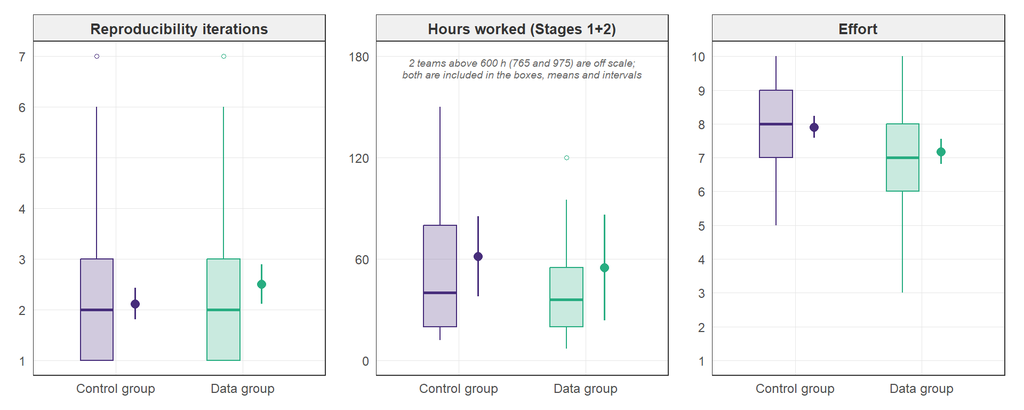

## Secondary hypothesis 7

**Summary of the preregistered analyses (see [§3.2.4](https://osf.io/cny7d/overview) for details):** The RT idiosyncrasy index $I_i$ is higher in the data group than in the control group. We test this hypothesis with an independent-samples $t$-test (equal variances) on the variable “RT idiosyncrasy index”, with one observation per RT. We hypothesize a larger mean in the data group.

**Results:** The independent-samples $t$-test indicates that the mean RT idiosyncrasy index is $m_{\text{data}}$ = 0.526 in the data group and $m_{\text{control}}$ = 0.541 in the control group ($t$ = -0.56, $p$ = 0.579). The figure below visualizes the per-RT distribution of the RT-level index by treatment condition (top), with the group means annotated, and the per-(RT × hypothesis) distribution of the per-hypothesis idiosyncrasy index $I_{i,h}$ by treatment condition for each of the four hypotheses (bottom). The solid vertical line marks 0.5, the value the index takes in expectation for an analysis chosen without reference to the observed 5%-sample; it is an approximate benchmark rather than one attained by construction, and no test against it is reported, as the pre-analysis plan does not specify one. The dashed lines mark the group means, labelled with their values.

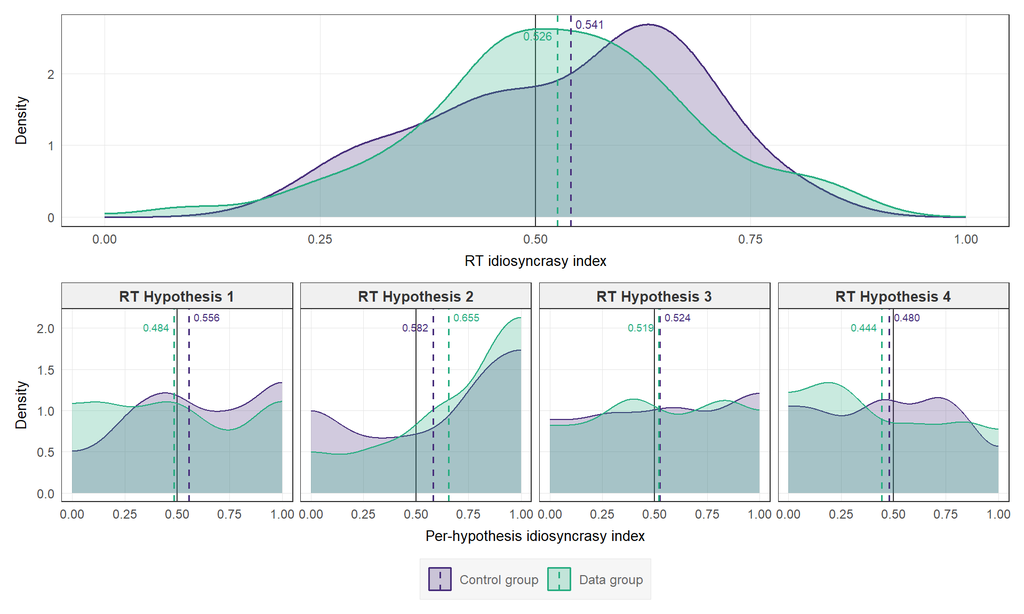

| *n* | *m* (data) | *m* (control) | diff | *se* | *df* | *t* | *p* | [95% CI] |
| --- | --- | --- | --- | --- | --- | --- | --- | --- |
| 119 | 0.526 | 0.541 | −0.015 | 0.028 | 117 | −0.556 | 0.579 | [-0.071, 0.040] |

**Non-preregistered robustness test — cells reaching the registered number of placebo draws.** The pre-analysis plan specifies 1,000 placebo subsamples per (RT $\times$ hypothesis) cell, but some teams’ code did not execute on every subsample, so 70 of the 479 cells with an index rest on fewer draws (see `02_summary_stats.Rmd` for the distribution by hypothesis and condition). The test below repeats the registered specification on the research teams whose four cells all reach 1,000 draws. The index keeps its registered definition — the mean of all four per-hypothesis indices — so only the sample changes; the restriction itself is not preregistered.

| *n* | *m* (data) | *m* (control) | diff | *se* | *df* | *t* | *p* | [95% CI] |
| --- | --- | --- | --- | --- | --- | --- | --- | --- |
| 84 | 0.516 | 0.557 | −0.041 | 0.033 | 82 | −1.247 | 0.216 | [-0.106, 0.024] |

## Secondary hypotheses 8 & 9

**Summary of the preregistered analyses (see [§3.2.4](https://osf.io/cny7d/overview) for details):**

**Secondary hypothesis 8.** In the *data* group, the per-hypothesis idiosyncrasy index $I_{i,h}$ is positively associated with prior beliefs about RT Hypothesis $h$. We test this by regressing $I_{i,h}$ on “Initial beliefs, RT Hypothesis $h$” (0–100%), restricted to data-group RTs, with standard errors clustered at the RT level. Each (RT, hypothesis) cell is one observation. We hypothesize a positive coefficient.

**Secondary hypothesis 9.** The idiosyncrasy index $I_{i,h}$ is more positively associated with prior beliefs about RT Hypothesis $h$ in the *data* group than in the *control* group. We test this by regressing $I_{i,h}$ on “Initial beliefs, RT Hypothesis $h$”, “Group”, and their interaction, using both groups, with standard errors clustered at the RT level. Each (RT, hypothesis) cell is one observation. We hypothesize a positive coefficient on the interaction term.

**Results:** The table below combines both regressions, displaying SH 8 in column **(a)** (data group only) and SH 9 in column **(b)** (full sample, with interaction). Beliefs are expressed as a 0–1 fraction, so each belief coefficient gives the change in the idiosyncrasy index associated with moving across the full range of prior belief (from 0% to 100%). A positive coefficient on the interaction term corresponds to a steeper belief–idiosyncrasy gradient in the data group than in the control group.

|  | (a) Sec 8: data group only | (b) Sec 9: full, with interaction |
| --- | --- | --- |
| Initial belief (0–1) | -0.226* (0.076) [-0.379, -0.074] -2.968 [0.004] | 0.042 (0.078) [-0.112, 0.197] 0.543 [0.588] |
| Group: Data |  | 0.124° (0.060) [0.006, 0.242] 2.082 [0.039] |
| Initial belief (0–1) × Group: Data |  | -0.269° (0.109) [-0.484, -0.053] -2.469 [0.015] |
| Constant | 0.640* (0.044) [0.552, 0.728] 14.560 [<0.001] | 0.516* (0.041) [0.435, 0.596] 12.716 [<0.001] |
| 𝑁 | 224 | 475 |
| 𝑅² | 0.039 | 0.019 |

**Notes:** Fixed effects (if any) omitted from output. Standard errors clustered at the RT level. Each cell reports the point estimate (with significance stars), the standard error in parentheses, the 95% CI in brackets, and the *t*-statistic with the *p*-value in brackets. **°** *p* < 0.05; * *p* < 0.005.

**Non-preregistered robustness test — cells reaching the registered number of placebo draws.** As for Secondary hypothesis 7 above, the table below repeats both registered specifications on the (RT $\times$ hypothesis) cells whose idiosyncrasy index rests on the full 1,000 placebo subsamples specified in the pre-analysis plan. Only the sample changes; the restriction itself is not preregistered.

|  | (a) Sec 8: data group only | (b) Sec 9: full, with interaction |
| --- | --- | --- |
| Initial belief (0–1) | -0.260* (0.069) [-0.399, -0.121] -3.749 [<0.001] | 0.026 (0.087) [-0.146, 0.198] 0.296 [0.768] |
| Group: Data |  | 0.120° (0.060) [0.001, 0.239] 2.004 [0.047] |
| Initial belief (0–1) × Group: Data |  | -0.286° (0.111) [-0.506, -0.066] -2.574 [0.011] |
| Constant | 0.654* (0.041) [0.572, 0.737] 15.865 [<0.001] | 0.534* (0.044) [0.447, 0.621] 12.187 [<0.001] |
| 𝑁 | 194 | 405 |
| 𝑅² | 0.049 | 0.025 |

**Notes:** Fixed effects (if any) omitted from output. Standard errors clustered at the RT level. Each cell reports the point estimate (with significance stars), the standard error in parentheses, the 95% CI in brackets, and the *t*-statistic with the *p*-value in brackets. **°** *p* < 0.05; * *p* < 0.005.

# Exploratory analyses

The exploratory analyses below should be interpreted with caution: they carry little inferential weight and are primarily intended to generate hypotheses for future studies (PAP §3.3).

## Exploratory analysis 1a-d

**Summary of the preregistered analyses (see [§3.3](https://osf.io/cny7d/overview) for details):** The support for RT Hypothesis 1/2/3/4 is associated with RT characteristics. OLS regression of “$z$-value, RT Hypothesis $h$” on “Group”, “Seniority”, “Field”, “Top publication”, “Experience with regression analysis, Stata, and large datasets”, “Experience with pre-analysis plans”, “Previous SOEP data experience”, and “RT size”, separately for each hypothesis, with robust standard errors. No directional hypotheses.

**Results:** The table below reports the four regressions (one per hypothesis) of the per-hypothesis $z$-value on the RT characteristics, with full coefficient estimates, robust (HC1) standard errors, and goodness-of-fit statistics.

|  | H1 | H2 | H3 | H4 |
| --- | --- | --- | --- | --- |
| Group: Data | -0.464 (0.720) [-1.891, 0.964] -0.644 [0.521] | 0.481 (0.412) [-0.335, 1.297] 1.168 [0.245] | -1.224 (1.443) [-4.083, 1.636] -0.848 [0.398] | -0.266 (1.019) [-2.286, 1.755] -0.260 [0.795] |
| Senior | 0.854 (0.738) [-0.609, 2.316] 1.156 [0.250] | -0.362 (0.451) [-1.255, 0.531] -0.803 [0.424] | 3.502° (1.390) [0.747, 6.257] 2.519 [0.013] | -0.367 (0.836) [-2.024, 1.290] -0.439 [0.661] |
| Economics/Finance | 0.993 (0.551) [-0.099, 2.085] 1.801 [0.074] | 0.387 (0.403) [-0.411, 1.186] 0.961 [0.338] | 3.267° (1.507) [0.280, 6.254] 2.168 [0.032] | -0.467 (0.644) [-1.743, 0.810] -0.724 [0.470] |
| Top publication | 0.383 (0.446) [-0.501, 1.267] 0.859 [0.392] | -0.047 (0.293) [-0.628, 0.535] -0.158 [0.874] | -0.832 (1.399) [-3.605, 1.940] -0.595 [0.553] | 1.462 (1.353) [-1.219, 4.144] 1.081 [0.282] |
| Prior SOEP experience | -0.371 (0.586) [-1.533, 0.791] -0.633 [0.528] | 0.070 (0.365) [-0.654, 0.794] 0.191 [0.849] | -1.684 (1.136) [-3.935, 0.568] -1.482 [0.141] | -1.740 (1.210) [-4.138, 0.659] -1.437 [0.153] |
| Experience: Analysis | 0.321 (0.344) [-0.361, 1.003] 0.933 [0.353] | -0.051 (0.193) [-0.433, 0.330] -0.267 [0.790] | 0.845 (0.703) [-0.548, 2.238] 1.202 [0.232] | 0.504 (0.338) [-0.166, 1.174] 1.491 [0.139] |
| Experience: PAPs | -0.033 (0.109) [-0.249, 0.183] -0.305 [0.761] | -0.066 (0.067) [-0.200, 0.067] -0.983 [0.328] | 0.051 (0.350) [-0.642, 0.744] 0.146 [0.884] | -0.390 (0.311) [-1.006, 0.225] -1.257 [0.211] |
| Team of two | 0.110 (0.550) [-0.979, 1.199] 0.200 [0.842] | -0.429 (0.358) [-1.138, 0.280] -1.198 [0.233] | 1.261 (1.840) [-2.385, 4.907] 0.685 [0.495] | -1.405 (0.986) [-3.360, 0.549] -1.425 [0.157] |
| Constant | -2.870 (3.375) [-9.558, 3.817] -0.851 [0.397] | 0.838 (1.925) [-2.976, 4.653] 0.436 [0.664] | -11.225 (6.290) [-23.689, 1.239] -1.785 [0.077] | -0.801 (2.145) [-5.051, 3.450] -0.373 [0.710] |
| 𝑁 | 120 | 120 | 120 | 120 |
| 𝑅² | 0.052 | 0.044 | 0.143 | 0.065 |

**Notes:** Fixed effects (if any) omitted from output. Standard errors robust (HC1). Each cell reports the point estimate (with significance stars), the standard error in parentheses, the 95% CI in brackets, and the *t*-statistic with the *p*-value in brackets. **°** *p* < 0.05; * *p* < 0.005.

## Exploratory analyses 2 & 3a-c

**Summary of the preregistered analyses (see [§3.3](https://osf.io/cny7d/overview) for details):**

**Exploratory analysis 2.** The variation in results is associated with RT characteristics. OLS regression of “Absolute deviation, RT Hypothesis 1/2/3/4” on “Group”, “Seniority”, “Field”, “Top publication”, “Experience with regression analysis, Stata, and large datasets”, “Experience with pre-analysis plans”, “Previous SOEP data experience”, and “RT size”, with four observations per RT (one per hypothesis) and standard errors clustered at the RT level. No directional hypotheses.

**Exploratory analyses 3a-c.** The rated *quality* (3a), *reasonableness* (3b), and *informativeness* (3c) of the PAP are associated with RT characteristics. For each rating outcome, we regress the per-rating outcome (10 × 4 observations per rater) on the same set of RT characteristics as in Exploratory 2, with two-way clustering at the rater and the RT-PAP level. No directional hypotheses.

**Results:** The table below combines all four exploratory regressions side-by-side: column **(a)** corresponds to Exploratory Analysis 2 (absolute deviation, RT-clustered SEs), and columns **(b)**, **(c)**, and **(d)** correspond to Exploratory Analyses 3a, 3b, and 3c (PAP quality, reasonableness, and informativeness; two-way clustered at rater and RT-PAP level).

|  | (a) Abs. deviation | (b) Quality | (c) Reasonableness | (d) Informativeness |
| --- | --- | --- | --- | --- |
| Group: Data | -0.458 (0.607) [-1.660, 0.745] -0.754 [0.452] | -0.005 (0.108) [-0.220, 0.209] -0.050 [0.961] | 0.045 (0.113) [-0.179, 0.269] 0.395 [0.694] | -0.055 (0.122) [-0.297, 0.187] -0.453 [0.651] |
| Senior | 0.332 (0.566) [-0.788, 1.452] 0.587 [0.558] | 0.237° (0.113) [0.014, 0.460] 2.101 [0.038] | 0.217 (0.138) [-0.056, 0.489] 1.571 [0.119] | 0.257° (0.119) [0.021, 0.493] 2.158 [0.033] |
| Economics/Finance | -0.244 (0.467) [-1.168, 0.680] -0.524 [0.602] | 0.142 (0.128) [-0.111, 0.395] 1.111 [0.268] | 0.091 (0.133) [-0.172, 0.354] 0.686 [0.494] | 0.193 (0.147) [-0.099, 0.484] 1.310 [0.193] |
| Top publication | 0.190 (0.558) [-0.916, 1.295] 0.339 [0.735] | 0.023 (0.100) [-0.175, 0.220] 0.226 [0.821] | 0.033 (0.110) [-0.184, 0.251] 0.303 [0.762] | 0.012 (0.109) [-0.203, 0.227] 0.109 [0.913] |
| Prior SOEP experience | -0.055 (0.559) [-1.163, 1.053] -0.098 [0.922] | -0.155 (0.098) [-0.350, 0.039] -1.582 [0.116] | -0.191 (0.108) [-0.405, 0.024] -1.759 [0.081] | -0.120 (0.114) [-0.346, 0.107] -1.048 [0.297] |
| Experience: Analysis | -0.010 (0.268) [-0.542, 0.521] -0.038 [0.969] | -0.059 (0.052) [-0.162, 0.044] -1.131 [0.260] | -0.094 (0.063) [-0.219, 0.031] -1.491 [0.139] | -0.024 (0.052) [-0.126, 0.079] -0.458 [0.648] |
| Experience: PAPs | 0.096 (0.141) [-0.183, 0.375] 0.684 [0.495] | -0.022 (0.025) [-0.072, 0.028] -0.860 [0.391] | -0.007 (0.028) [-0.063, 0.048] -0.252 [0.802] | -0.037 (0.028) [-0.092, 0.019] -1.304 [0.195] |
| Team of two | -0.289 (0.578) [-1.433, 0.854] -0.501 [0.617] | -0.057 (0.145) [-0.344, 0.229] -0.395 [0.693] | 0.027 (0.161) [-0.292, 0.346] 0.169 [0.866] | -0.142 (0.156) [-0.450, 0.167] -0.907 [0.366] |
| Constant | 1.795 (2.450) [-3.056, 6.647] 0.733 [0.465] | 7.090* (0.392) [6.315, 7.865] 18.108 [<0.001] | 6.779* (0.469) [5.851, 7.707] 14.454 [<0.001] | 7.402* (0.419) [6.572, 8.231] 17.656 [<0.001] |
| 𝑁 | 480 | 5080 | 5080 | 5080 |
| 𝑅² | 0.009 | 0.007 | 0.005 | 0.007 |

**Notes:** Fixed effects (if any) omitted from output. Standard errors (a) clustered at the RT level; (b)–(d) two-way clustered at rater and RT-PAP level. Each cell reports the point estimate (with significance stars), the standard error in parentheses, the 95% CI in brackets, and the *t*-statistic with the *p*-value in brackets. **°** *p* < 0.05; * *p* < 0.005.

## Exploratory analysis 4a-d

**Summary of the preregistered analyses (see [§3.3](https://osf.io/cny7d/overview) for details):** The initial RT beliefs are positively correlated with the results. For each hypothesis we estimate a point-biserial correlation between “$p$-value < 0.05, RT Hypothesis $h$” (i.e., the binary indicator for a $p$ < 0.05 result in the hypothesized direction) and “Initial beliefs, RT Hypothesis $h$”. We hypothesize a positive correlation.

**Results:** The table below reports the point-biserial correlation between the SSC indicator (PAP §2.1) and the Stage-1 prior belief, separately for each hypothesis.

|  | *n* | *r* (point-biserial) | *t* | *df* | *p* | [95% CI] |
| --- | --- | --- | --- | --- | --- | --- |
| RT Hypothesis 1 | 119 | −0.062 | −0.672 | 117 | 0.503 | [-0.239, 0.119] |
| RT Hypothesis 2 | 119 | −0.015 | −0.160 | 117 | 0.873 | [-0.194, 0.166] |
| RT Hypothesis 3 | 119 | 0.138 | 1.505 | 117 | 0.135 | [-0.043, 0.310] |
| RT Hypothesis 4 | 119 | 0.148 | 1.624 | 117 | 0.107 | [-0.032, 0.320] |

## Exploratory analysis 5a-d

**Summary of the preregistered analyses (see [§3.3](https://osf.io/cny7d/overview) for details):** The RT beliefs after Stage 2 are positively correlated with the results. For each hypothesis we estimate a point-biserial correlation between “$p$-value < 0.05, RT Hypothesis $h$” (i.e., the binary indicator for a $p$ < 0.05 result in the hypothesized direction) and “Beliefs after Stage 2, RT Hypothesis $h$”. We hypothesize a positive correlation.

**Results:** The table below reports the point-biserial correlation between the SSC indicator and the Stage-2 posterior belief, separately for each hypothesis.

|  | *n* | *r* (point-biserial) | *t* | *df* | *p* | [95% CI] |
| --- | --- | --- | --- | --- | --- | --- |
| RT Hypothesis 1 | 120 | 0.078 | 0.850 | 118 | 0.397 | [-0.103, 0.254] |
| RT Hypothesis 2 | 120 | −0.010 | −0.109 | 118 | 0.914 | [-0.189, 0.170] |
| RT Hypothesis 3 | 120 | 0.349 | 4.045 | 118 | 0.000 | [0.181, 0.497] |
| RT Hypothesis 4 | 120 | 0.162 | 1.786 | 118 | 0.077 | [-0.017, 0.332] |

# Statistical power and minimum detectable effect sizes

**Summary of the preregistered analyses (see [§3.4](https://osf.io/cny7d/overview) for details):** We will report the minimum detectable effect size (MDE) for which we had 90% statistical power to detect in the primary and secondary hypothesis tests above (excluding the pooled tests in Primary 1a-d and Secondary 1a-d, where the MDE is difficult to interpret as the test is based on the mean $z$-statistic, and excluding the exploratory analyses and robustness tests). For tests at the 5% level (suggestive evidence) we report MDE = $se$ × 3.24; for tests at the 0.5% level (statistically significant evidence) we report MDE = $se$ × 4.09.

**Results:** The table below summarizes the standard error and the implied 90%-power MDEs at the 5% and 0.5% significance thresholds for the primary and secondary hypothesis tests for which the MDE is interpretable in the same units as the underlying coefficient.

| Hypothesis test | *se* | Unit | MDE (α = 5%) | MDE (α = 0.5%) |
| --- | --- | --- | --- | --- |
| Primary 2: variation | 0.541 | z-units | 1.754 | 2.214 |
| Primary 3: PAP quality | 0.118 | rating points | 0.382 | 0.482 |
| Secondary 2: reasonableness | 0.126 | rating points | 0.409 | 0.516 |
| Secondary 3: informativeness | 0.132 | rating points | 0.427 | 0.539 |
| Secondary 4: reproducibility iterations | 0.249 | iterations | 0.808 | 1.020 |
| Secondary 5: hours worked | 19.513 | hours | 63.222 | 79.808 |
| Secondary 6: effort (0-10) | 0.243 | scale points | 0.788 | 0.995 |
| Secondary 7: RT idiosyncrasy index | 0.028 | index units | 0.090 | 0.114 |
| Secondary 8: belief slope (data group) | 0.076 | index per unit | 0.247 | 0.312 |
| Secondary 9: belief × group interaction | 0.109 | index per unit | 0.353 | 0.445 |

**Note:** The full-sample MDEs for the variation in results (Primary 2) and hours worked (Secondary 5) are inflated by a few extreme observations. The following outlier-excluded MDEs are non-preregistered (PAP §3.4 reports MDEs only for the primary/secondary tests, not for robustness tests): excluding outliers, the MDEs (α = 5% / 0.5%) are 0.316 / 0.399 z-units for Primary 2 (using the preregistered outlier-exclusion criteria) and 18.5 / 23.3 hours for Secondary 5 (excluding the two observations above 600 hours). The belief-slope tests (Secondary 8–9) are expressed per unit of the 0–1 belief scale (i.e., across the full 0%–100% range).